# Advanced data analysis_HW 3

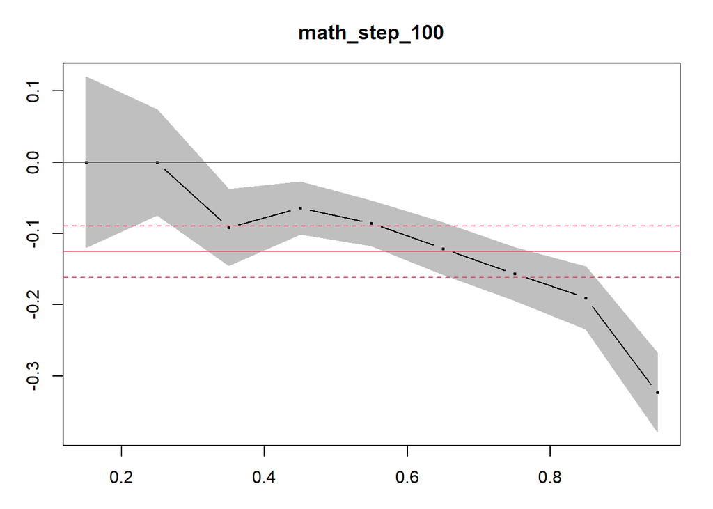

```r
summary(q_plot) %>%
  plot(c("math_step_100"))
```

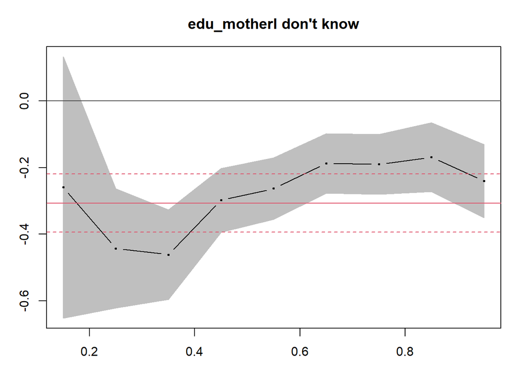

```r
summary(q_plot) %>%
  plot(c("edu_motherI don't know"))
```

Here also OLS correctly estimates the difference between mother’s education (compared to “Higher education”) for all levels of bulling (CI of OLS are crossing CI for quantile regression).

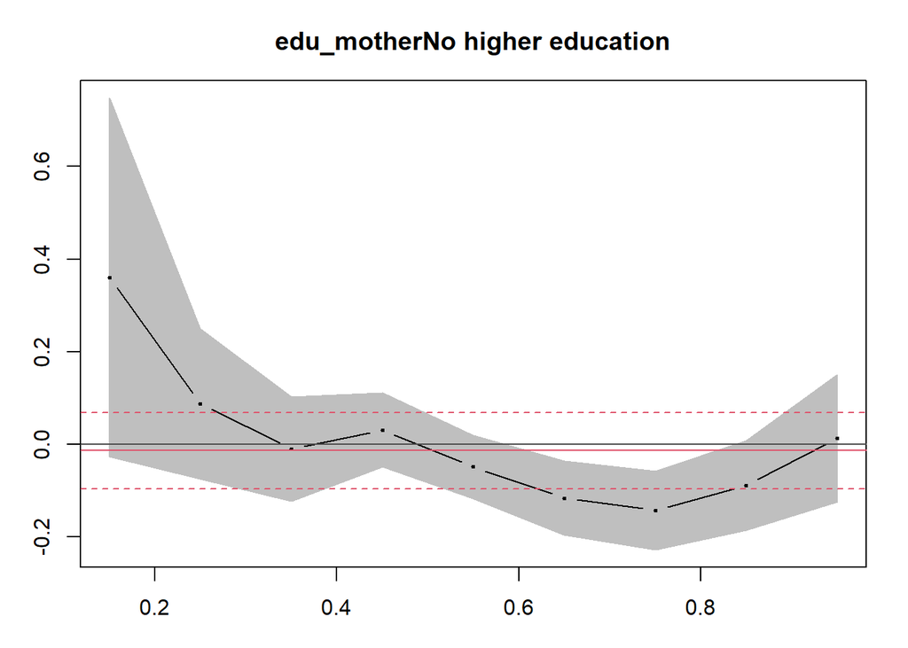

```r
summary(q_plot) %>%
  plot(c("edu_motherNo higher education"))
```

# 7. Finally, answer the question: Who is more susceptible to bullying in American schools? Are there any factors protecting from bullying?

Thus, OLS regression is more capable of explaining factors of the average values of the level of bullying. At the same time, it does not always do this successfully for high rates of bullying. Like, in general, females compared for males have higher level of bullying, but there is no gender differences on a high level of bullying. Also, good academic performance, in mathematics in particular, reduces the level of bullying. Moreover, owning DVDs increases the level of bullying, perhaps this has something to do with income, because DVDs are already becoming a thing of the past and more modern media are appearing. Perhaps not everyone can afford to upgrade their disk systems to modern ones. But this is only a hypothesis, since income was not included in this study.

In my opinion, according to the research results, there are no direct factors aimed at reducing bullying or protecting from that. It is possible that an increase in academic performance will help reduce the level of bullying, but on the other hand, there may be other factors that cause bullying and were not considered in this study